# EOSC 213 — Computational Methods for Geological Engineering

## 5. Explicit Midpoint Method

The Explicit Midpoint method advances the solution by first estimating the state at the midpoint of the time step and then using the function evaluated at this midpoint to update the solution for the next time step. Recall the Explicit Midpoint update, $$ r_{n + \frac{1}{2}} = r_n + \frac{h}{2} f(t_n, r_n)\\ r_{n + 1} = r_n + h f\bigg(t_n + \frac{h}{2}, r_{n + \frac{1}{2}}\bigg)\\ $$

Apply the Explicit Midpoint method component-wise to the predator–prey system. Using the right-hand side function you implemented earlier, write a Python function that advances the prey and predator populations in time using the Explicit Midpoint method. Use the right-hand side function you defined earlier, and return the full time history of the numerical solution, i.e., return the time tensor `t`, prey population tensor `x`, and predator population tensor `y`.

```python
# TODO 5: Implement the function explicit_midpoint(h, x0, y0, t0, T, alpha, beta, gamma, delta)
# that returns time tensor `t`, prey population tensor `x`, and predator population tensor `y`
# using the Explicit Midpoint method.
def explicit_midpoint(h, x0, y0, t0, T, alpha, beta, gamma, delta):
    N = int((T - t0) / h)
    t = torch.linspace(t0, T, N+1)
    x = torch.zeros(N+1)
    y = torch.zeros(N+1)
    x[0], y[0] = x0, y0

    for n in range(N):
        dx1, dy1 = f_lv(x[n], y[n], alpha, beta, gamma, delta)
        x_half = x[n] + 0.5 * h * dx1
        y_half = y[n] + 0.5 * h * dy1

        dx2, dy2 = f_lv(x_half, y_half, alpha, beta, gamma, delta)
        x[n+1] = x[n] + h * dx2
        y[n+1] = y[n] + h * dy2

    return t, x, y
```

### Explicit Midpoint: Time Evolution

Repeat the simulations using the Explicit Midpoint method and compare with Forward Euler.

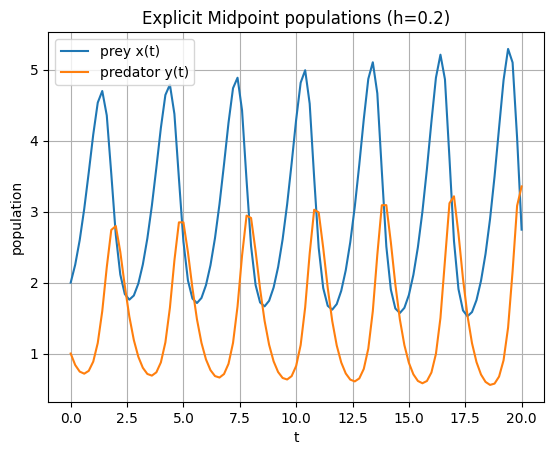

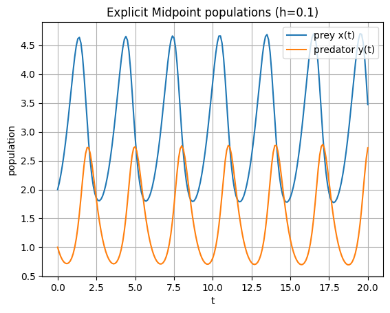

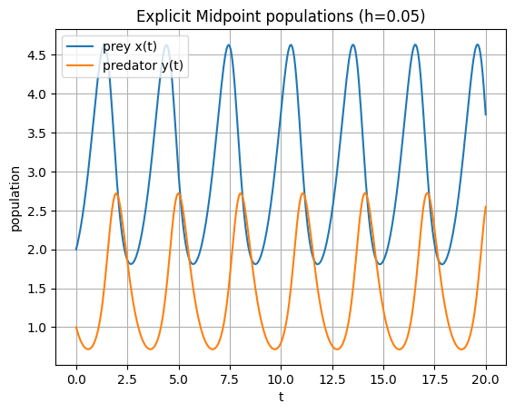

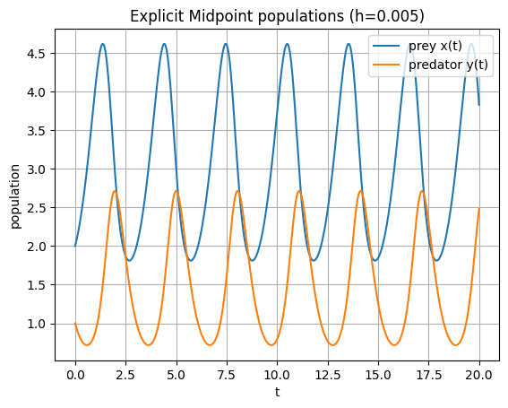

```python
for h in hs:
    t, x, y = explicit_midpoint(h, x0, y0, t0, T, alpha, beta, gamma, delta)
    plt.figure()
    plt.plot(t, x, label="prey x(t)")
    plt.plot(t, y, label="predator y(t)")
    plt.title(f"Explicit Midpoint populations (h={h})")
    plt.xlabel("t")
    plt.ylabel("population")
    plt.legend()
    plt.grid()
    plt.show()
```

### Interpretation of Explicit Midpoint Time Evolution and Contrast with Forward Euler

Compare the time evolution of the prey and predator populations obtained using the Explicit Midpoint method with those obtained using the Forward Euler method. In 3–4 sentences, describe the qualitative differences you observe in terms of smoothness of oscillations and long-time behavior as the step size varies. Comment on which method more faithfully captures the expected predator–prey dynamics and why.

```python
# TODO 6: In 3–4 sentences, compare the Explicit Midpoint and Forward Euler solutions. Comment on the
# differences in smoothness of oscillations and long-time behavior as the step size h varies, and
# explain which method better captures the predator–prey dynamics and why.
```

```python
"""
Explicit Midpoint produces smoother, more regular predator-prey oscillations than Forward Euler for the same step size,
and it is much less likely to generate non-physical behavior such as negative populations or sudden blow-ups. In contrast,
Forward Euler shows strong numerical drift: the oscillation amplitudes can grow over time or become unstable unless the
step size is made very small. As the step size decreases, both methods improve, but Explicit Midpoint typically looks
“stable and cyclic” at step sizes where Forward Euler still shows noticeable distortion. Overall, Explicit Midpoint more
faithfully captures the expected closed-cycle predator-prey dynamics because it samples the vector field at a midpoint
estimate, which reduces the step-to-step error and long-time drift.
"""
```

```
'\nExplicit Midpoint produces smoother, more regular predator-prey oscillations than Forward Euler for the same step size, \nand it is much less likely to generate non-physical behavior such as negative populations or sudden blow-ups. In contrast, \nForward Euler shows strong numerical drift: the os…
```

## 6. Phase Portraits and Equilibrium

Instead of plotting populations versus time, we can plot predator $y(t)$ versus prey $x(t)$. The plot $y(t)$ vs. $x(t)$ is known as the **phase portrait**. Each point on the phase portrait represents the state of the system at a given time.

The equilibrium point satisfies $x'=0$ and $y'=0$, yielding,

$$ (x^*,y^*) = \left(\frac{\gamma}{\delta}, \frac{\alpha}{\beta}\right) = (3.0, 1.5). $$

An equilibrium point represents a state where both populations remain constant in time, meaning the rates of change of the prey and predator populations are zero. In the predator–prey model, this corresponds to a balanced situation where prey growth exactly offsets predation and predator reproduction exactly offsets natural death.

The code below plots the equilibrium points and the phase portraits for the Explicit Midpoint method for different values of $h$.

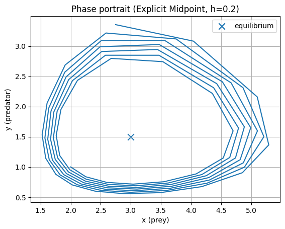

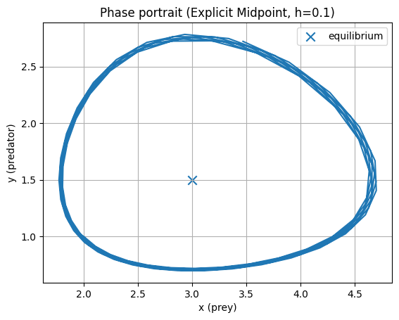

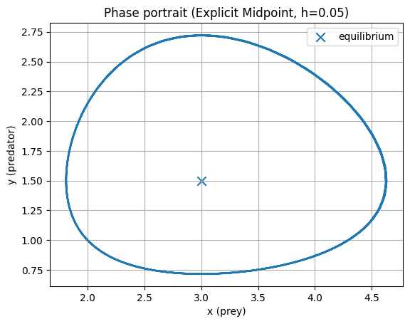

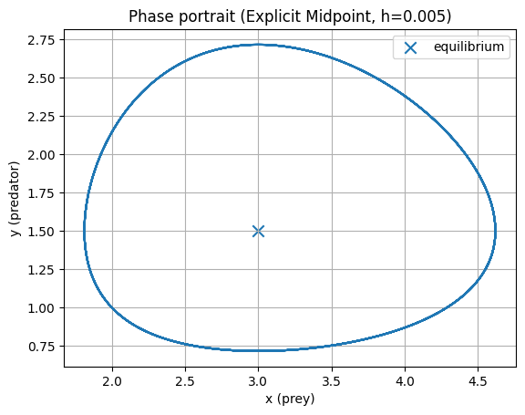

```python
x_star = gamma / delta
y_star = alpha / beta

for h in hs:
    t, x, y = explicit_midpoint(h, x0, y0, t0, T, alpha, beta, gamma, delta)
    plt.figure()
    plt.plot(x, y)
    plt.scatter([x_star], [y_star], marker="x", s=80, label="equilibrium")
    plt.xlabel("x (prey)")
    plt.ylabel("y (predator)")
    plt.title(f"Phase portrait (Explicit Midpoint, h={h})")
    plt.legend()
    plt.grid()
    plt.show()
```

### Interpretation of the Phase Portraits for various values of $h$

Using the phase portraits $y(t)$ vs. $x(t)$ generated above for the Explicit Midpoint method, describe in a few sentences what the trajectories tell you about the predator–prey dynamics. In particular, comment on (i) how the trajectory behaves relative to the equilibrium point $(x^\star, y^\star)$, and (ii) how the qualitative shape of the phase portrait changes (or does not change) as the step size $h$ decreases.

```python
# TODO 7: # In 3–4 sentences, interpret the phase portraits generated above.
# Describe how the trajectories behave relative to the equilibrium point (x*, y*),
# and comment on how the qualitative shape of the phase portrait changes as the
# step size h decreases.
```

```python
"""
The phase portraits show trajectories that loop around the equilibrium point (x^*, y^*), indicating oscillatory predator-prey cycles
rather than convergence to the equilibrium. This means the populations repeatedly rise and fall, with the equilibrium acting like a
central “balance point” around which the system evolves. As the step size h decreases, the phase curves become smoother and more
consistently closed, suggesting the numerical solution better captures the expected cyclic behavior. For larger h, the trajectory
may show slight spiraling or distortion, which indicates numerical error or drift introduced by time stepping rather than true model
behavior."""
```

```
'\nThe phase portraits show trajectories that loop around the equilibrium point (x^*, y^*), indicating oscillatory predator-prey cycles \nrather than convergence to the equilibrium. This means the populations repeatedly rise and fall, with the equilibrium acting like a \ncentral “balance point” arou…
```

## 7. Evaluating a Conserved Quantity

For the exact Lotka–Volterra system, the quantity,

$$H(x,y) = \delta x - \gamma \ln x + \beta y - \alpha \ln y$$

remains constant along solution trajectories. This invariant labels different predator–prey cycles.

Physically, this conserved quantity represents a balance between prey growth and predation, and between predator reproduction and natural death, over an entire cycle of interaction. Its conservation implies that, in the idealized model, neither species gains a long-term advantage, and the system repeats the same oscillatory pattern indefinitely rather than converging to extinction or unbounded growth.

Numerical methods generally do **not** preserve invariants exactly. Tracking $H(x, y)$ allows us to quantify long-time numerical drift.

Define this invariant function $H(x, y)$ as a function of $x$ and $y$ below.

```python
# TODO 8: Implement the function H_invariant(x, y, alpha, beta, gamma, delta)
# and return the value of H
def H_invariant(x, y, alpha, beta, gamma, delta):
    return delta * x - gamma * torch.log(x) + beta * y - alpha * torch.log(y)
```

### Plotting H as a function of time t

Below we plot the invariant $H(x(t), y(t))$ as a function of $t$ for the Explicit Midpoint method.

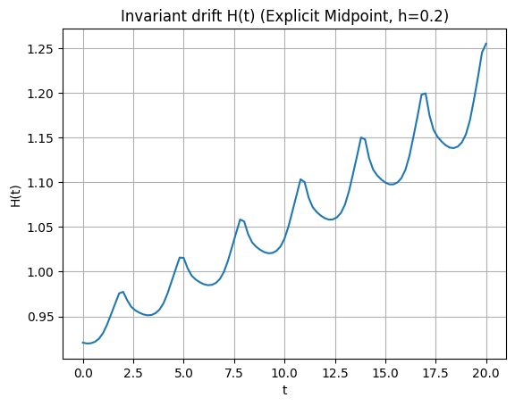

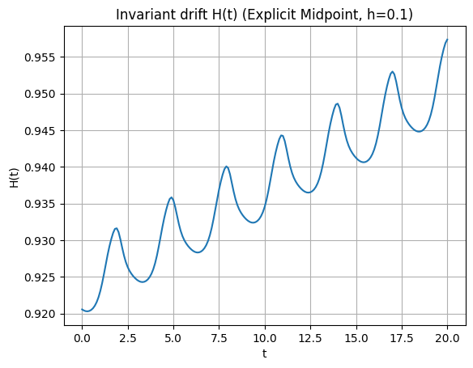

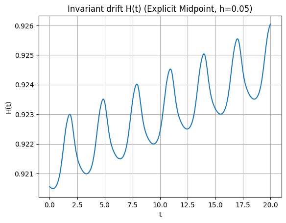

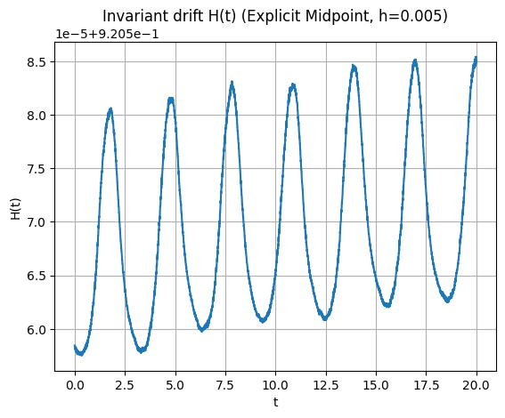

```python
for h in hs:
    t, x, y = explicit_midpoint(h, x0, y0, t0, T, alpha, beta, gamma, delta)
    mask = (x > 0) & (y > 0)
    H = torch.full_like(x, float("nan"))
    H[mask] = H_invariant(x[mask], y[mask], alpha, beta, gamma, delta)

    plt.figure()
    plt.plot(t, H)
    plt.title(f"Invariant drift H(t) (Explicit Midpoint, h={h})")
    plt.xlabel("t")
    plt.ylabel("H(t)")
    plt.grid()
    plt.show()
```

### Interpretation about the drift in the Invariant H

The plots above show $H(t)$ computed from the numerical solution produced by the Explicit Midpoint method for several step sizes $h$. In a few sentences, describe what these curves indicate about (i) how well the numerical method preserves the conserved quantity, and (ii) how the behavior of $H(t)$ changes as $h$ decreases. What does the long-time drift in $H(t)$ suggest about the numerical solution in phase space?

```python
# TODO 9: In 3–4 sentences, interpret the plots of the invariant H(t) shown above.
# Comment on how well the Explicit Midpoint method preserves H, how the drift
# changes as the step size h decreases, and what this long-time drift implies
# about the behavior of the numerical solution in phase space.
```

```python
"""
For the exact Lotka-Volterra system, H(x(t), y(t)) should remain constant, so any visible change in H(t) is purely a numerical artifact.
For larger step sizes (e.g., h=0.2), H(t) shows a clear upward drift over time, meaning the method is not preserving the invariant and
is gradually distorting the dynamics. As h decreases (e.g., h=0.1 or h=0.05), the drift becomes smaller and the curve stays closer to a
constant level, indicating improved long-time accuracy. For very small h (e.g., h=0.005), the drift is tiny and H(t) is nearly constant,
so the numerical trajectory better matches the expected closed cycles. In phase space, a systematic drift in H(t) typically corresponds
to trajectories that slowly spiral outward or inward rather than remaining on a closed orbit.
"""
```

```
'\nFor the exact Lotka-Volterra system, H(x(t), y(t)) should remain constant, so any visible change in H(t) is purely a numerical artifact. \nFor larger step sizes (e.g., h=0.2), H(t) shows a clear upward drift over time, meaning the method is not preserving the invariant and \nis gradually distorti…
```

## 8. Final Takeaway

This problem demonstrates that numerical solutions of nonlinear, coupled ODE systems can behave very differently from the exact solution if the time step or numerical method is not chosen carefully. Even when the true dynamics consist of regular, closed oscillations, a numerical method may introduce artificial growth, damping, or drift that accumulates over long times. By comparing Forward Euler and the Explicit Midpoint method, we see that higher-order methods can better capture qualitative features of the dynamics at larger step sizes, though they may still fail to preserve important invariants exactly. Overall, this example highlights the importance of both step-size selection and method choice when simulating nonlinear systems over long time intervals.